# Radiology CYOA Analysis

Ramie Fathy

October 21, 2019

## R Markdown

Read in Data, change column names:

```r
preceptorData <- read.csv("Pulmonary Course Preceptor Survey (Responses) - Form Responses 1.csv", header = TRUE)
colnames(preceptorData) <- c("Timestamp", "CYOA", "FormatSatisfaction",
                             "StudentPreparation", "SessionDifficulty",
                             "BestTeachingMethod", "FacilitatorUtility",
                             "StudentEngagement", "PreceptorParticipation",
                             "StudentPace", "QuestionQuality", "CaseDiscussion",
                             "ImageInterpretation", "ExpectationClarity",
                             "PreceptorPreparation", "SelfDirectedLearning",
                             "ClinicalDecisionMaking", "Liked", "WouldChange")
studentCYOAData <- read.xlsx("Pulm Rad survey responses-2.xlsx", sheetIndex = 1)
studentCYOAData <- studentCYOAData %>% mutate(smallGroupType = "CYOA")
studentLinearData <- read.xlsx("Pulm Rad survey responses-2.xlsx", sheetIndex = 2)
studentLinearData <- studentLinearData  %>% mutate(smallGroupType = "Linear")
studentData <- rbind(studentCYOAData, studentLinearData)
colnames(studentData) <- c("Engaged", "Difficulty", "Satisfied", "Radiology",
                           "Linear", "SelfDirected", "Decisions",
                           "ClinicalDecisionMaking", "Pace", "ChestImagingTest",
                           "RadiologyElective", "Facilitator",
                           "LearningEnvironment", "EducationalMethod", "Liked",
                           "ToChange", "Q1", "Q2", "Q3", "Q4", "TotalCorrect",
                           "PercentCorrect", "totalWithoutOne",
                           "percentWithoutOne", "SmallGroupType")
#exclude incomplete cases
studentData <- studentData[complete.cases(studentData),]
```

## Reformat data

```r
p_table(combinedData,
        vars = c("FormatSatisfaction", "StudentPreparation", "SessionDifficulty",
                 "FacilitatorUtility", "StudentEngagement", "PreceptorParticipation",
                 "StudentPace", "QuestionQuality", "CaseDiscussion",
                 "ImageInterpretation", "ExpectationClarity", "PreceptorPreparation",
                 "SelfDirectedLearning", "ClinicalDecisionMaking"),
        strata = c("CYOA"))
```

|  | level | FALSE | TRUE | p | test |
| --- | --- | --- | --- | --- | --- |
| n |  | 4 | 4 |  |  |
| FormatSatisfaction (mean (sd)) |  | 2.25 (0.96) | 2.00 (1.15) | 0.750 |  |
| StudentPreparation (mean (sd)) |  | 4.25 (0.50) | 4.50 (0.58) | 0.537 |  |
| SessionDifficulty (mean (sd)) |  | 4.25 (0.50) | 4.75 (0.50) | 0.207 |  |
| FacilitatorUtility (mean (sd)) |  | 5.00 (0.00) | 4.25 (0.96) | 0.168 |  |
| StudentEngagement (mean (sd)) |  | 4.25 (0.50) | 4.25 (0.50) | 1.000 |  |
| PreceptorParticipation (mean (sd)) |  | 4.25 (0.50) | 3.50 (0.58) | 0.097 |  |
| StudentPace (mean (sd)) |  | 2.50 (0.58) | 3.50 (1.00) | 0.134 |  |
| QuestionQuality (mean (sd)) |  | 4.50 (0.58) | 4.25 (0.96) | 0.670 |  |
| CaseDiscussion (mean (sd)) |  | 4.50 (0.58) | 4.75 (0.50) | 0.537 |  |
| ImageInterpretation (mean (sd)) |  | 3.25 (0.96) | 4.25 (0.50) | 0.114 |  |
| ExpectationClarity (mean (sd)) |  | 4.50 (0.58) | 4.50 (0.58) | 1.000 |  |
| PreceptorPreparation (mean (sd)) |  | 4.50 (0.58) | 4.50 (0.58) | 1.000 |  |
| SelfDirectedLearning (mean (sd)) |  | 3.50 (1.29) | 4.50 (0.58) | 0.207 |  |
| ClinicalDecisionMaking (mean (sd)) |  | 4.25 (0.50) | 4.50 (0.58) | 0.537 |  |

No significant differences at the p = 0.05 level, but there were only 8 responses.

Let’s make some plots…

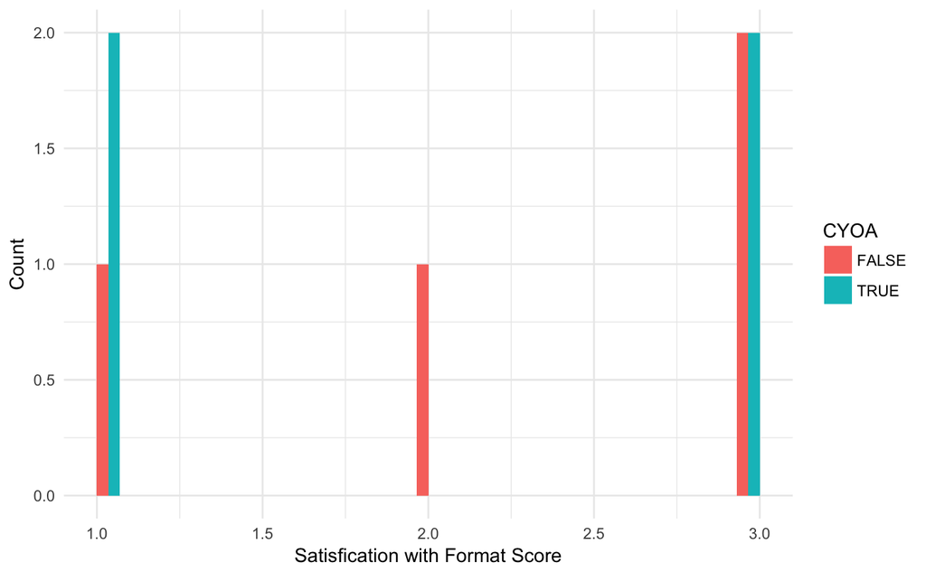

```r
ggplot(data = combinedData, mapping = aes(x = FormatSatisfaction, fill = CYOA))+
  geom_histogram(position = 'dodge') +
  theme_minimal() +
  labs(x = "Satisfication with Format Score", y = "Count")
```

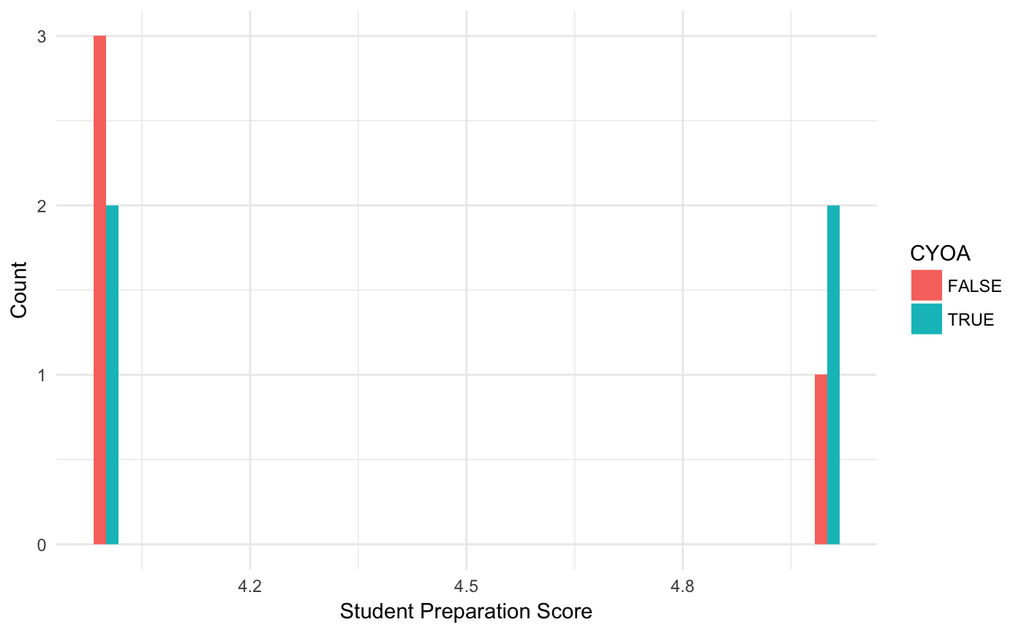

```r
ggplot(data = combinedData, mapping = aes(x = StudentPreparation, fill = CYOA))+
  geom_histogram(position = 'dodge') +
  theme_minimal() +
  labs(x = "Student Preparation Score", y = "Count")
```

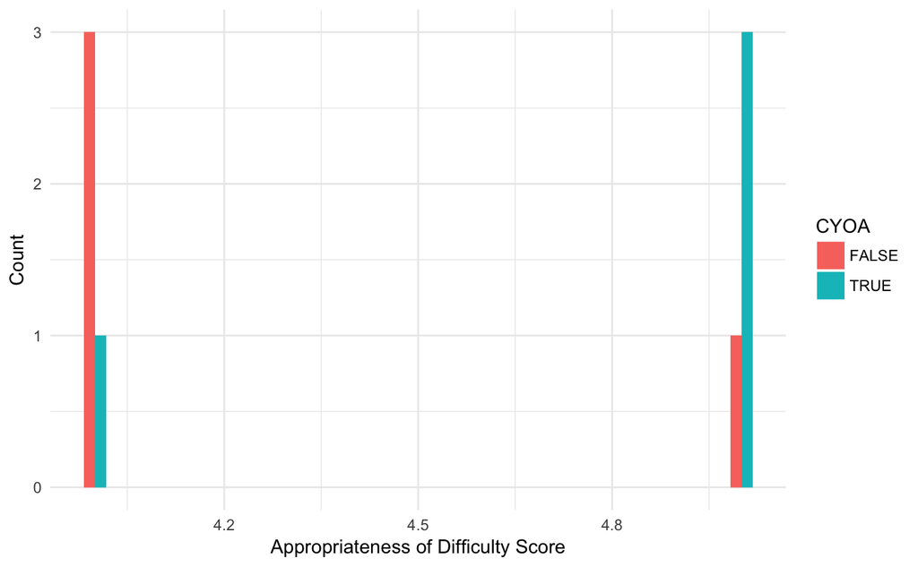

```r
ggplot(data = combinedData, mapping = aes(x = SessionDifficulty, fill = CYOA))+
  geom_histogram(position = 'dodge') +
  theme_minimal() +
  labs(x = "Appropriateness of Difficulty Score", y = "Count")
```

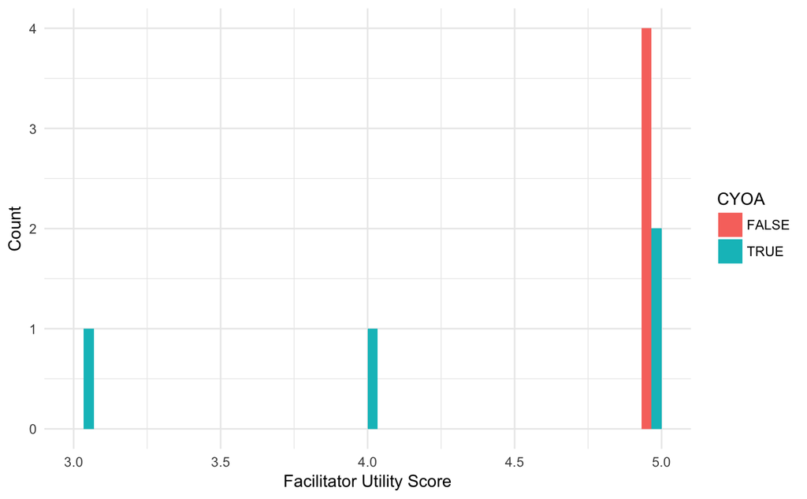

```r
ggplot(data = combinedData, mapping = aes(x = FacilitatorUtility, fill = CYOA)) +
    geom_histogram(position = 'dodge') +
  theme_minimal() +
  labs(x = "Facilitator Utility Score", y = "Count")
```

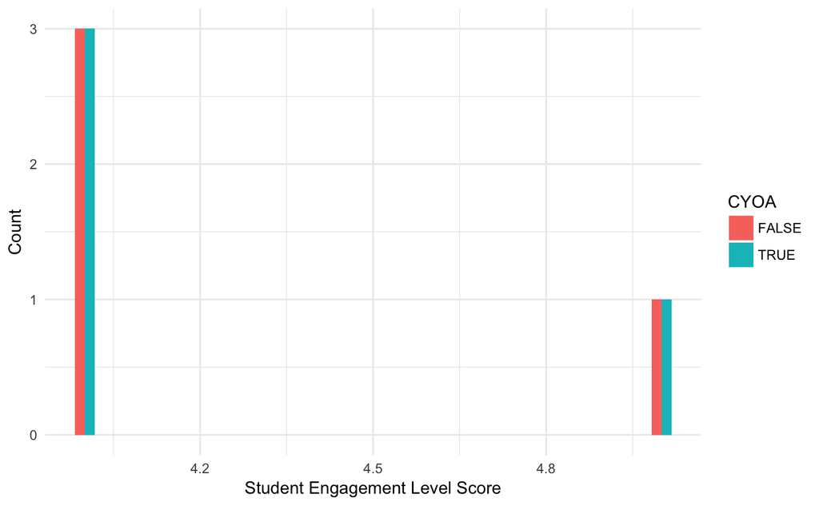

```r
ggplot(data = combinedData, mapping = aes(x = StudentEngagement, fill = CYOA))+
    geom_histogram(position = 'dodge') +
  theme_minimal() +
  labs(x = "Student Engagement Level Score", y = "Count")
```

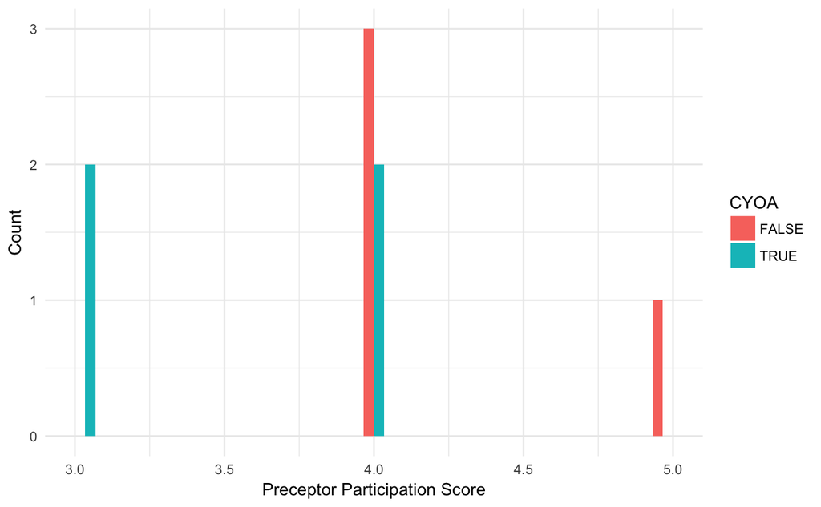

```r
ggplot(data = combinedData, mapping = aes(x = PreceptorParticipation, fill = CYOA))+
    geom_histogram(position = 'dodge') +
  theme_minimal() +
  labs(x = "Preceptor Participation Score", y = "Count")
```

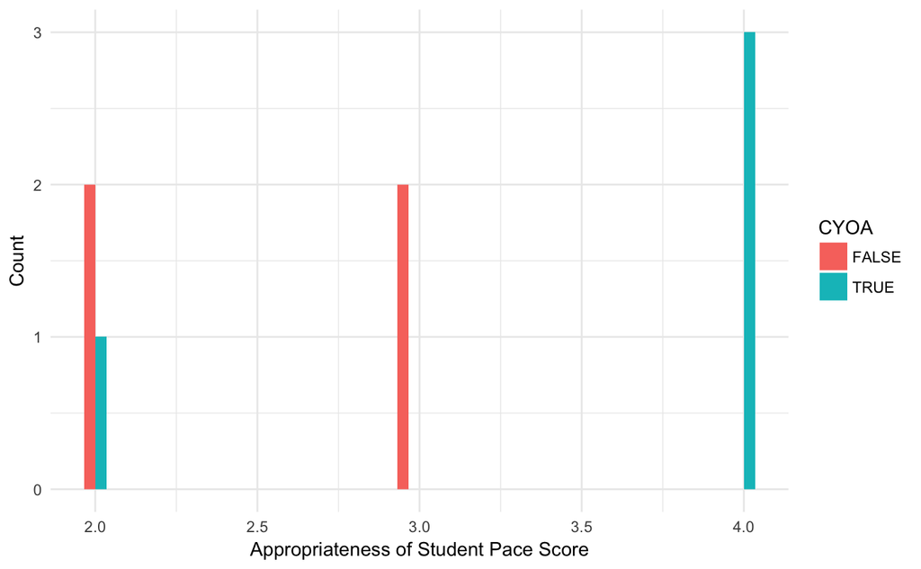

```r
ggplot(data = combinedData, mapping = aes(x = StudentPace, fill = CYOA))+
    geom_histogram(position = 'dodge') +
  theme_minimal() +
  labs(x = "Appropriateness of Student Pace Score", y = "Count")
```

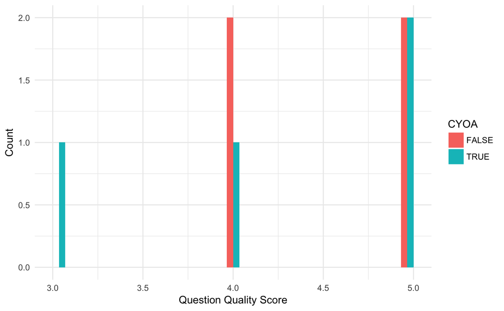

```r
ggplot(data = combinedData, mapping = aes(x = QuestionQuality, fill = CYOA))+
    geom_histogram(position = 'dodge') +
  theme_minimal() +
  labs(x = "Question Quality Score", y = "Count")
```

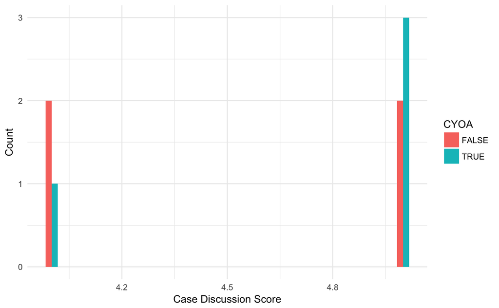

```r
ggplot(data = combinedData, mapping = aes(x = CaseDiscussion, fill = CYOA))+
    geom_histogram(position = 'dodge') +
  theme_minimal() +
  labs(x = "Case Discussion Score", y = "Count")
```

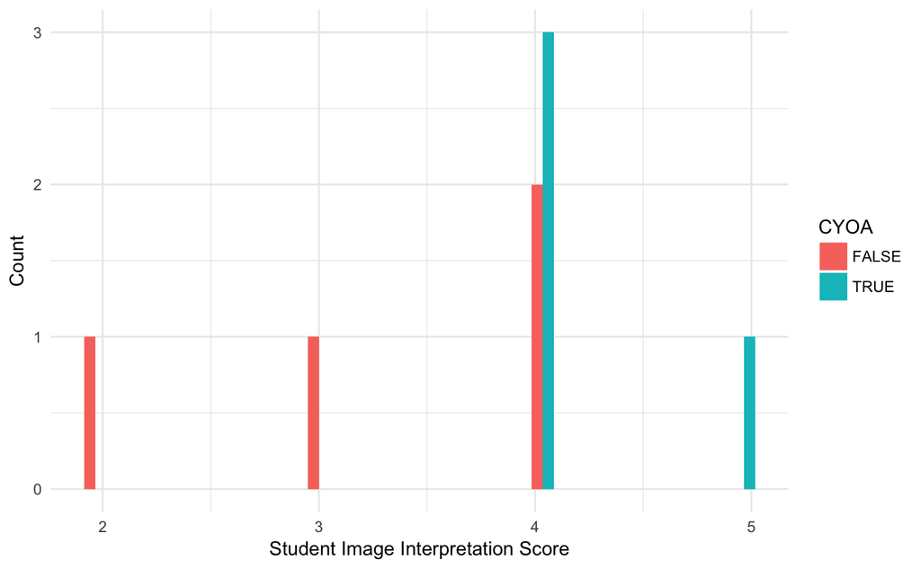

```r
ggplot(data = combinedData, mapping = aes(x = ImageInterpretation, fill = CYOA))+
    geom_histogram(position = 'dodge') +
  theme_minimal() +
  labs(x = "Student Image Interpretation Score", y = "Count")
```

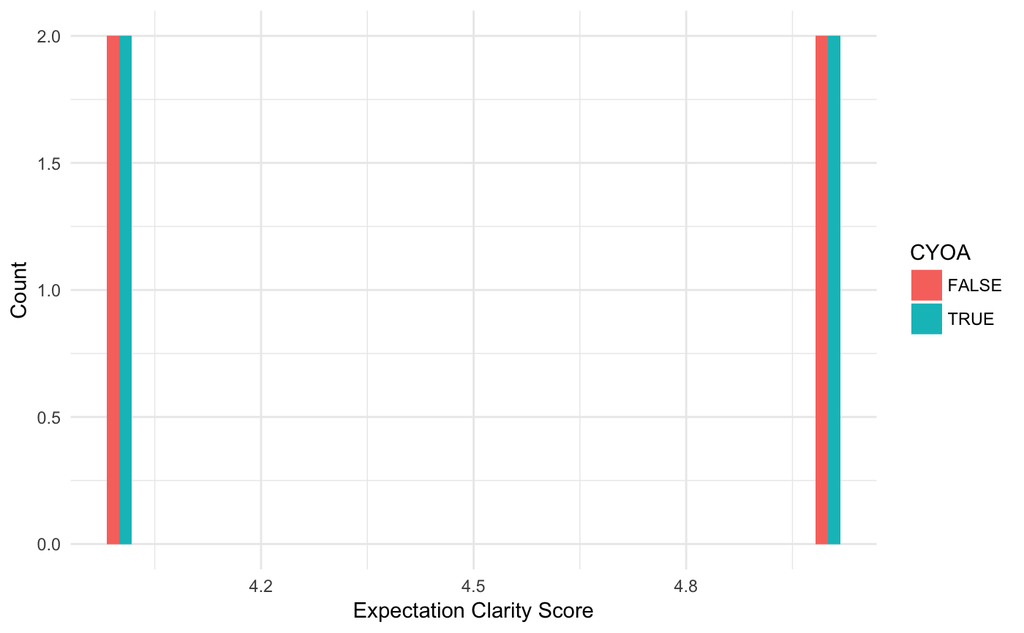

```r
ggplot(data = combinedData, mapping = aes(x = ExpectationClarity, fill = CYOA))+
    geom_histogram(position = 'dodge') +
  theme_minimal() +
  labs(x = "Expectation Clarity Score", y = "Count")
```

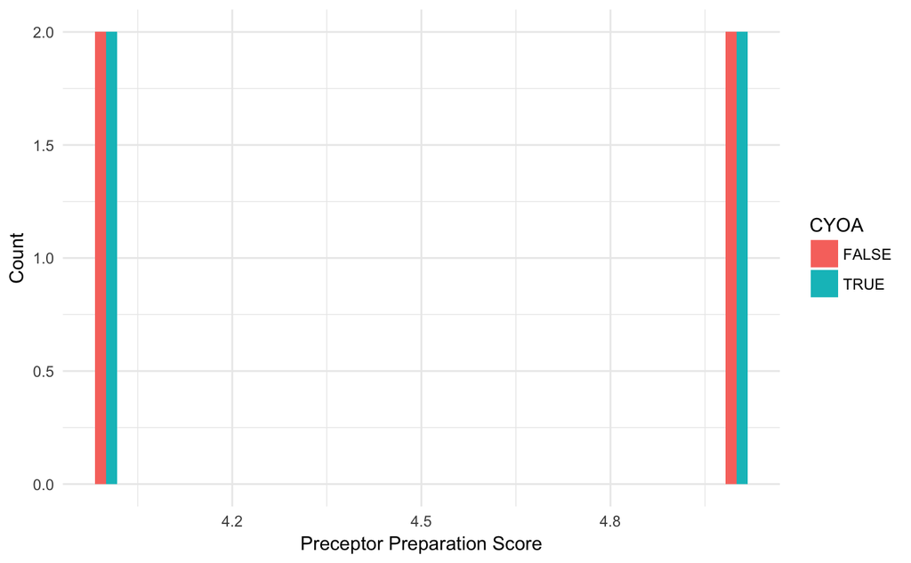

```r
ggplot(data = combinedData, mapping = aes(x = PreceptorPreparation, fill = CYOA))+
    geom_histogram(position = 'dodge') +
  theme_minimal() +
  labs(x = "Preceptor Preparation Score", y = "Count")
```

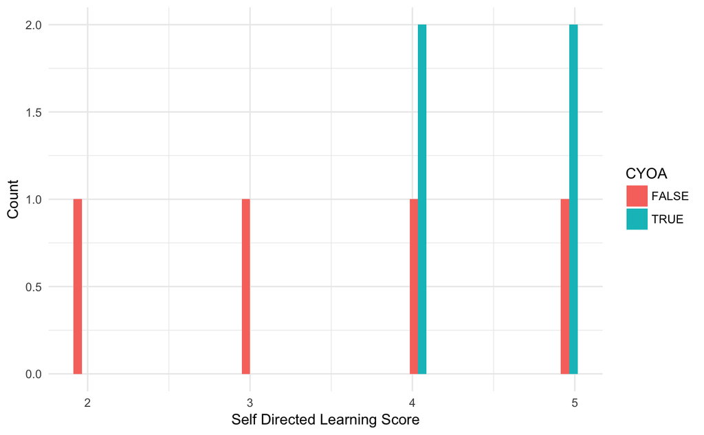

```r
ggplot(data = combinedData, mapping = aes(x = SelfDirectedLearning, fill = CYOA))+
    geom_histogram(position = 'dodge') +
  theme_minimal() +
  labs(x = "Self Directed Learning Score", y = "Count")
```

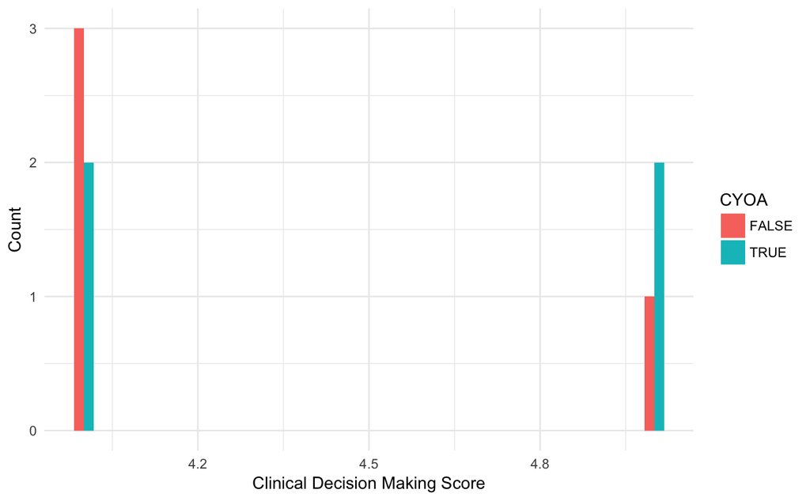

```r
ggplot(data = combinedData, mapping = aes(x = ClinicalDecisionMaking, fill = CYOA))+
    geom_histogram(position = 'dodge') +
  theme_minimal() +
  labs(x = "Clinical Decision Making Score", y = "Count")
```

# Student Data Analysis

```r
p_table(studentData,
        vars = c("Engaged", "Difficulty", "Satisfied", "Radiology",
                           "Linear", "SelfDirected", "Decisions",
                           "ClinicalDecisionMaking", "Pace", "ChestImagingTest",
                           "RadiologyElective", "Facilitator", "PercentCorrect",
                 "percentWithoutOne", "Q1", "Q2", "Q3", "Q4"),
        strata = c("SmallGroupType"))
```

|  | level | CYOA | Linear | p | test |
| --- | --- | --- | --- | --- | --- |
| n |  | 67 | 59 |  |  |
| Engaged (mean (sd)) |  | 4.48 (0.70) | 3.78 (0.72) | <0.001 |  |
| Difficulty (mean (sd)) |  | 4.40 (0.65) | 3.95 (0.73) | <0.001 |  |
| Satisfied (mean (sd)) |  | 4.64 (0.57) | 3.68 (0.86) | <0.001 |  |
| Radiology (mean (sd)) |  | 3.78 (0.98) | 3.64 (0.76) | 0.405 |  |
| Linear (mean (sd)) |  | 3.37 (1.07) | 3.14 (0.84) | 0.172 |  |
| SelfDirected (mean (sd)) |  | 4.25 (0.82) | 3.25 (1.09) | <0.001 |  |
| Decisions (mean (sd)) |  | 4.60 (0.63) | 4.32 (0.63) | 0.016 |  |
| ClinicalDecisionMaking (mean (sd)) |  | 4.49 (0.59) | 3.54 (0.90) | <0.001 |  |
| Pace (mean (sd)) |  | 4.54 (0.70) | 4.10 (0.76) | 0.001 |  |
| ChestImagingTest (mean (sd)) |  | 4.04 (0.86) | 3.53 (0.95) | 0.002 |  |
| RadiologyElective (mean (sd)) |  | 3.01 (1.19) | 2.75 (0.94) | 0.165 |  |
| Facilitator (mean (sd)) |  | 4.25 (1.05) | 4.58 (0.50) | 0.033 |  |
| PercentCorrect (mean (sd)) |  | 47.76 (26.01) | 52.97 (25.46) | 0.260 |  |
| percentWithoutOne (mean (sd)) |  | 60.70 (31.74) | 64.97 (28.65) | 0.431 |  |
| Q1 (mean (sd)) |  | 0.09 (0.29) | 0.17 (0.38) | 0.181 |  |
| Q2 (mean (sd)) |  | 0.45 (0.50) | 0.58 (0.50) | 0.152 |  |
| Q3 (mean (sd)) |  | 0.54 (0.50) | 0.54 (0.50) | 0.955 |  |
| Q4 (mean (sd)) |  | 0.84 (0.37) | 0.83 (0.38) | 0.937 |  |

Students in CYOA Small Groups were more engaged and satisfied with the experience, and they did appreciate the pace more, though they did find the small group to be more difficult.

Facilitators were more highly rated in the Linear Small Group cohort.

There was no difference in the percent correct on the quiz between the two groups.

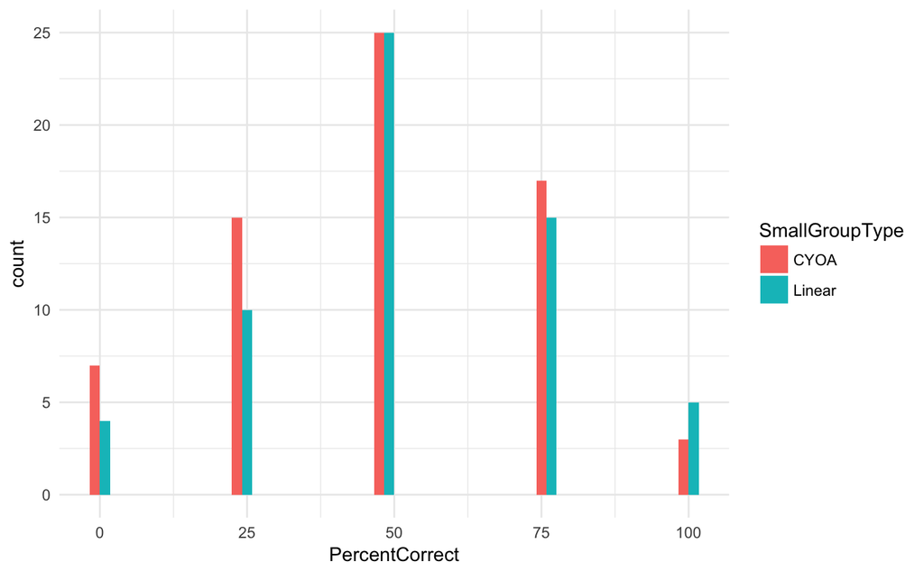

```r
# Distribution of Performances on Quiz by Small Group Type
ggplot(data = studentData, mapping = aes(x = PercentCorrect, fill = SmallGroupType))+
geom_histogram(position = 'dodge') +
  theme_minimal()
```

```r
#mode (same in both groups)
getmode((studentData %>% filter(SmallGroupType == "CYOA"))$PercentCorrect)
```

```
[1] 50
```

```r
getmode((studentData %>% filter(SmallGroupType == "Linear"))$PercentCorrect)
```

```
[1] 50
```

```r
#median (same in both groups)
median((studentData %>% filter(SmallGroupType == "CYOA"))$PercentCorrect)
```

```
[1] 50
```

```r
median((studentData %>% filter(SmallGroupType == "Linear"))$PercentCorrect)
```

```
[1] 50
```

```r
#mean
mean((studentData %>% filter(SmallGroupType == "CYOA"))$PercentCorrect)
```

```
[1] 47.76119
```

```r
mean((studentData %>% filter(SmallGroupType == "Linear"))$PercentCorrect)
```

```
[1] 52.9661
```

```r
#compare means with a t-test, no difference
t.test((studentData %>% filter(SmallGroupType == "CYOA"))$PercentCorrect,
       (studentData %>% filter(SmallGroupType == "Linear"))$PercentCorrect)
```

```
    Welch Two Sample t-test

data:  (studentData %>% filter(SmallGroupType == "CYOA"))$PercentCorrect and (studentData %>% filter(SmallGroupType == "Linear"))$PercentCorrect
t = -1.1334, df = 122.6, p-value = 0.2593
alternative hypothesis: true difference in means is not equal to 0
95 percent confidence interval:
 -14.295528   3.885712
sample estimates:
mean of x mean of y
 47.76119  52.96610
```

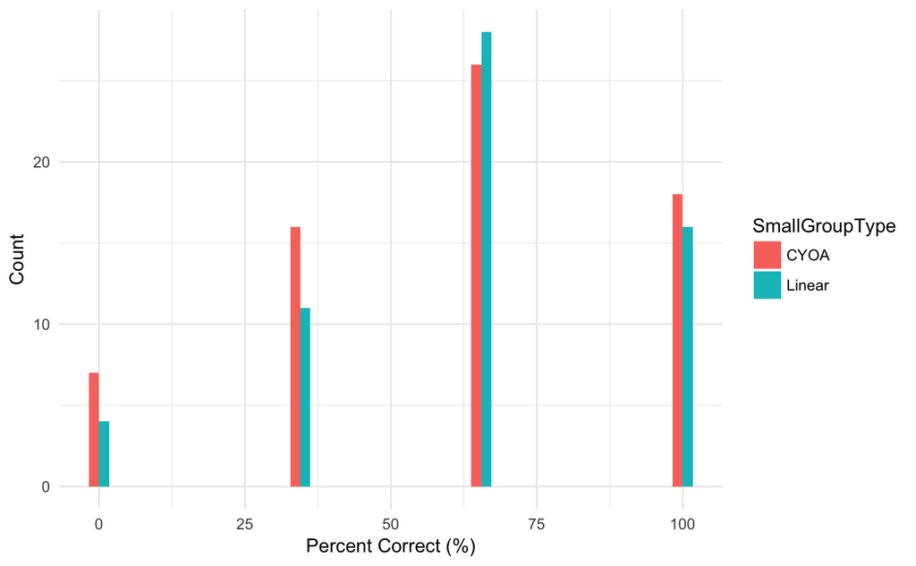

```r
# Distribution of Performances on Quiz by Small Group Type
ggplot(data = studentData, mapping = aes(x = percentWithoutOne, fill = SmallGroupType))+
  geom_histogram(position = 'dodge') +
  theme_minimal() +
  labs(x = "Percent Correct (%)", y = "Count")
```

```r
#mode (same in both groups)
getmode((studentData %>% filter(SmallGroupType == "CYOA"))$percentWithoutOne)
```

```
[1] 66.66667
```

```r
getmode((studentData %>% filter(SmallGroupType == "Linear"))$percentWithoutOne)
```

```
[1] 66.66667
```

```r
#median (same in both groups)
median((studentData %>% filter(SmallGroupType == "CYOA"))$percentWithoutOne)
```

```
[1] 66.66667
```

```r
median((studentData %>% filter(SmallGroupType == "Linear"))$percentWithoutOne)
```

```
[1] 66.66667
```

```r
#mean
mean((studentData %>% filter(SmallGroupType == "CYOA"))$percentWithoutOne)
```

```
[1] 60.69652
```

```r
mean((studentData %>% filter(SmallGroupType == "Linear"))$percentWithoutOne)
```

```
[1] 64.97175
```

```r
#compare means with a t-test, no difference
t.test((studentData %>% filter(SmallGroupType == "CYOA"))$percentWithoutOne,
       (studentData %>% filter(SmallGroupType == "Linear"))$percentWithoutOne)
```

```
    Welch Two Sample t-test

data:  (studentData %>% filter(SmallGroupType == "CYOA"))$percentWithoutOne and (studentData %>% filter(SmallGroupType == "Linear"))$percentWithoutOne
t = -0.79456, df = 123.92, p-value = 0.4284
alternative hypothesis: true difference in means is not equal to 0
95 percent confidence interval:
 -14.925053   6.374585
sample estimates:
mean of x mean of y
 60.69652  64.97175
```

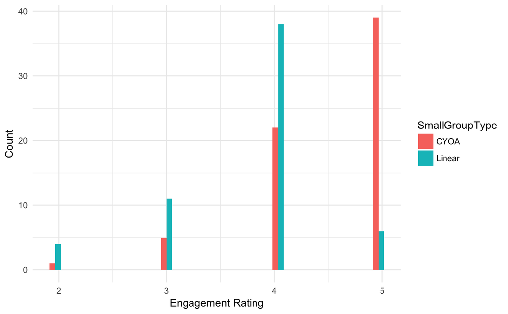

```r
# Engagement Distribution by Small Group Type
ggplot(data = studentData, mapping = aes(x = Engaged, fill = SmallGroupType))+
  geom_histogram(position = 'dodge') +
  theme_minimal() +
  labs(x = "Engagement Rating", y = "Count")
```

```
Ignoring unknown parameters: binwidth, bins, pad
```

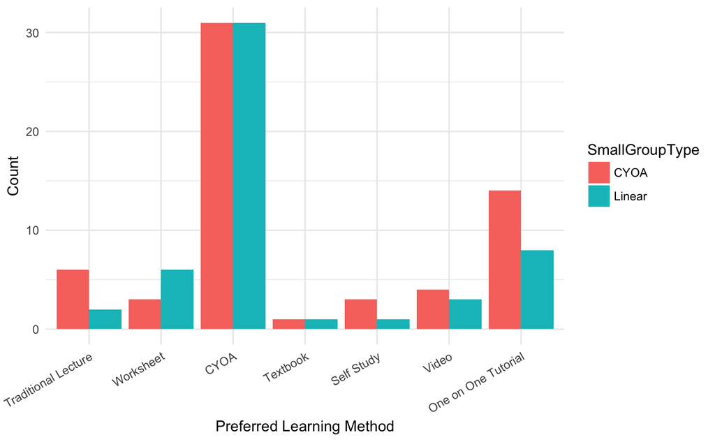

```r
#exclude surveys where students selected multiple Preferred Educational Methods
studentDataLim <- studentData  %>% filter(EducationalMethod %in%
                                       c("a", "b", "c", "d", "e", "f", "g")) %>%
  mutate(EducationalMethodType = fct_recode(EducationalMethod,
                                            "Traditional Lecture" = "a",
                                            "Worksheet" = "b",
                                            "CYOA" = "c",
                                            "Textbook" = "d",
                                            "Self Study" = "e",
                                            "Video" = "f",
                                            "One on One Tutorial" = "g"))
# make a histogram of Preferred Educational Method - CYOA wins out in both
ggplot(data = studentDataLim) +
  geom_histogram(stat = "count",
                 mapping = aes(x = EducationalMethodType,
                               fill = SmallGroupType), position = 'dodge') +
 # facet_wrap(~SmallGroupType, ncol = 1) +
  theme_minimal() +
  theme(axis.text.x = element_text(angle = 30, hjust = 1))  +
  labs(x = "Preferred Learning Method", y = "Count")
```

```r
p_table(studentDataLim,
        vars = c("EducationalMethodType"),
        strata = c("SmallGroupType"))
```

|  | level | CYOA | Linear | p | test |
| --- | --- | --- | --- | --- | --- |
| n |  | 62 | 52 |  |  |
| EducationalMethodType (%) | Traditional Lecture | 6 ( 9.7) | 2 ( 3.8) | NaN |  |
|  | a, c | 0 ( 0.0) | 0 ( 0.0) |  |  |
|  | Worksheet | 3 ( 4.8) | 6 (11.5) |  |  |
|  | b, c | 0 ( 0.0) | 0 ( 0.0) |  |  |
|  | b, f, g | 0 ( 0.0) | 0 ( 0.0) |  |  |
|  | CYOA | 31 (50.0) | 31 (59.6) |  |  |
|  | c, d, e, f, g | 0 ( 0.0) | 0 ( 0.0) |  |  |
|  | c, g | 0 ( 0.0) | 0 ( 0.0) |  |  |
|  | Textbook | 1 ( 1.6) | 1 ( 1.9) |  |  |
|  | Self Study | 3 ( 4.8) | 1 ( 1.9) |  |  |
|  | Video | 4 ( 6.5) | 3 ( 5.8) |  |  |
|  | One on One Tutorial | 14 (22.6) | 8 (15.4) |  |  |
|  | b, c, e, g | 0 ( 0.0) | 0 ( 0.0) |  |  |
|  | b, c, g | 0 ( 0.0) | 0 ( 0.0) |  |  |
|  | b, e | 0 ( 0.0) | 0 ( 0.0) |  |  |
|  | b, g | 0 ( 0.0) | 0 ( 0.0) |  |  |
|  | c, e | 0 ( 0.0) | 0 ( 0.0) |  |  |
|  | c, f | 0 ( 0.0) | 0 ( 0.0) |  |  |

```r
# across both groups, CYOA was selected as the preferred Educational Method by
# 54% of respondents
nrow(studentDataLim %>% filter(EducationalMethodType == "CYOA")) /
  nrow(studentDataLim)
```

```
[1] 0.5438596
```

```r
model <- glm((PercentCorrect >= 75) ~ Engaged + Difficulty + Satisfied +
               Pace + ChestImagingTest + Facilitator + SmallGroupType,
                family = "binomial",
                data = studentData)
summary(model)
```

```
Call:
glm(formula = (PercentCorrect >= 75) ~ Engaged + Difficulty +
    Satisfied + Pace + ChestImagingTest + Facilitator + SmallGroupType,
    family = "binomial", data = studentData)

Deviance Residuals:
    Min       1Q   Median       3Q      Max
-1.4092  -0.8699  -0.7483   1.1959   1.8757

Coefficients:
                     Estimate Std. Error z value Pr(>|z|)
(Intercept)           -1.7974     1.6936  -1.061   0.2886
Engaged                0.2739     0.4082   0.671   0.5023
Difficulty             0.2815     0.4199   0.670   0.5026
Satisfied             -0.1318     0.4074  -0.323   0.7464
Pace                   0.1132     0.3614   0.313   0.7541
ChestImagingTest       0.2859     0.2869   0.996   0.3191
Facilitator           -0.6186     0.2722  -2.272   0.0231 *
SmallGroupTypeLinear   0.7694     0.5215   1.475   0.1401
---
Signif. codes:  0 ‘***’ 0.001 ‘**’ 0.01 ‘*’ 0.05 ‘.’ 0.1 ‘ ’ 1

(Dispersion parameter for binomial family taken to be 1)

    Null deviance: 157.48  on 125  degrees of freedom
Residual deviance: 149.78  on 118  degrees of freedom
AIC: 165.78

Number of Fisher Scoring iterations: 4
```

```r
exp(cbind("Odds ratio" = coef(model), confint.default(model, level = 0.95)))
```

```
                     Odds ratio       2.5 %    97.5 %
(Intercept)           0.1657359 0.005995233 4.5817056
Engaged               1.3150488 0.590830262 2.9269885
Difficulty            1.3251192 0.581872835 3.0177397
Satisfied             0.8765468 0.394449287 1.9478657
Pace                  1.1198565 0.551513058 2.2738874
ChestImagingTest      1.3309401 0.758462073 2.3355175
Facilitator           0.5387221 0.315969025 0.9185125
SmallGroupTypeLinear  2.1584365 0.776744772 5.9979137
```

Multivariate analysis only highlights facilitator score as predictive of performance on quiz.

```r
model <- glm((percentWithoutOne >= 66) ~ Engaged + Difficulty + Satisfied +
               Pace + ChestImagingTest + Facilitator + SmallGroupType,
                family = "binomial",
                data = studentData)
summary(model)
```

```
Call:
glm(formula = (percentWithoutOne >= 66) ~ Engaged + Difficulty +
    Satisfied + Pace + ChestImagingTest + Facilitator + SmallGroupType,
    family = "binomial", data = studentData)

Deviance Residuals:
    Min       1Q   Median       3Q      Max
-2.1672  -1.1562   0.6823   0.8391   1.5442

Coefficients:
                     Estimate Std. Error z value Pr(>|z|)
(Intercept)            1.6895     1.7304   0.976   0.3289
Engaged               -0.8854     0.4538  -1.951   0.0511 .
Difficulty            -0.2417     0.4072  -0.594   0.5528
Satisfied              0.4308     0.4323   0.997   0.3190
Pace                  -0.2877     0.3706  -0.776   0.4375
ChestImagingTest       0.6642     0.2811   2.363   0.0181 *
Facilitator            0.1545     0.2670   0.579   0.5627
SmallGroupTypeLinear   0.3345     0.5475   0.611   0.5412
---
Signif. codes:  0 ‘***’ 0.001 ‘**’ 0.01 ‘*’ 0.05 ‘.’ 0.1 ‘ ’ 1

(Dispersion parameter for binomial family taken to be 1)

    Null deviance: 154.28  on 125  degrees of freedom
Residual deviance: 143.85  on 118  degrees of freedom
AIC: 159.85

Number of Fisher Scoring iterations: 4
```

```r
exp(cbind("Odds ratio" = coef(model), confint.default(model, level = 0.95)))
```

```
                     Odds ratio     2.5 %     97.5 %
(Intercept)           5.4170032 0.1823193 160.948025
Engaged               0.4125414 0.1694948   1.004104
Difficulty            0.7852961 0.3535396   1.744331
Satisfied             1.5384461 0.6593561   3.589588
Pace                  0.7499631 0.3627542   1.550484
ChestImagingTest      1.9428769 1.1199282   3.370547
Facilitator           1.1671208 0.6915749   1.969665
SmallGroupTypeLinear  1.3972045 0.4778251   4.085554
```

Comparing Likert Scale Data

# t-tests to Compare Means

```r
t.test((studentData %>% filter(SmallGroupType == "CYOA"))$Engaged,
            (studentData %>% filter(SmallGroupType == "Linear"))$Engaged)
```

```
    Welch Two Sample t-test

data:  (studentData %>% filter(SmallGroupType == "CYOA"))$Engaged and (studentData %>% filter(SmallGroupType == "Linear"))$Engaged
t = 5.4828, df = 121.21, p-value = 2.321e-07
alternative hypothesis: true difference in means is not equal to 0
95 percent confidence interval:
 0.4459338 0.9499681
sample estimates:
mean of x mean of y
 4.477612  3.779661
```

```r
t.test((studentData %>% filter(SmallGroupType == "CYOA"))$Difficulty,
            (studentData %>% filter(SmallGroupType == "Linear"))$Difficulty)
```

```
    Welch Two Sample t-test

data:  (studentData %>% filter(SmallGroupType == "CYOA"))$Difficulty and (studentData %>% filter(SmallGroupType == "Linear"))$Difficulty
t = 3.6602, df = 117.37, p-value = 0.000379
alternative hypothesis: true difference in means is not equal to 0
95 percent confidence interval:
 0.2082855 0.6993795
sample estimates:
mean of x mean of y
 4.402985  3.949153
```

```r
t.test((studentData %>% filter(SmallGroupType == "CYOA"))$Satisfied,
            (studentData %>% filter(SmallGroupType == "Linear"))$Satisfied)
```

```
    Welch Two Sample t-test

data:  (studentData %>% filter(SmallGroupType == "CYOA"))$Satisfied and (studentData %>% filter(SmallGroupType == "Linear"))$Satisfied
t = 7.3128, df = 98.539, p-value = 7.027e-11
alternative hypothesis: true difference in means is not equal to 0
95 percent confidence interval:
 0.7022904 1.2253595
sample estimates:
mean of x mean of y
 4.641791  3.677966
```

```r
t.test((studentData %>% filter(SmallGroupType == "CYOA"))$Radiology,
            (studentData %>% filter(SmallGroupType == "Linear"))$Radiology)
```

```
    Welch Two Sample t-test

data:  (studentData %>% filter(SmallGroupType == "CYOA"))$Radiology and (studentData %>% filter(SmallGroupType == "Linear"))$Radiology
t = 0.84905, df = 122.07, p-value = 0.3975
alternative hypothesis: true difference in means is not equal to 0
95 percent confidence interval:
 -0.1758308  0.4399340
sample estimates:
mean of x mean of y
 3.776119  3.644068
```

```r
t.test((studentData %>% filter(SmallGroupType == "CYOA"))$Linear,
            (studentData %>% filter(SmallGroupType == "Linear"))$Linear)
```

```
    Welch Two Sample t-test

data:  (studentData %>% filter(SmallGroupType == "CYOA"))$Linear and (studentData %>% filter(SmallGroupType == "Linear"))$Linear
t = 1.3932, df = 122.43, p-value = 0.1661
alternative hypothesis: true difference in means is not equal to 0
95 percent confidence interval:
 -0.09996184  0.57504405
sample estimates:
mean of x mean of y
 3.373134  3.135593
```

```r
t.test((studentData %>% filter(SmallGroupType == "CYOA"))$SelfDirected,
            (studentData %>% filter(SmallGroupType == "Linear"))$SelfDirected)
```

```
    Welch Two Sample t-test

data:  (studentData %>% filter(SmallGroupType == "CYOA"))$SelfDirected and (studentData %>% filter(SmallGroupType == "Linear"))$SelfDirected
t = 5.7397, df = 106.98, p-value = 8.949e-08
alternative hypothesis: true difference in means is not equal to 0
95 percent confidence interval:
 0.6542874 1.3447007
sample estimates:
mean of x mean of y
 4.253731  3.254237
```

```r
t.test((studentData %>% filter(SmallGroupType == "CYOA"))$Pace,
            (studentData %>% filter(SmallGroupType == "Linear"))$Pace)
```

```
    Welch Two Sample t-test

data:  (studentData %>% filter(SmallGroupType == "CYOA"))$Pace and (studentData %>% filter(SmallGroupType == "Linear"))$Pace
t = 3.3271, df = 119.08, p-value = 0.001168
alternative hypothesis: true difference in means is not equal to 0
95 percent confidence interval:
 0.1763673 0.6948697
sample estimates:
mean of x mean of y
 4.537313  4.101695
```

```r
t.test((studentData %>% filter(SmallGroupType == "CYOA"))$ChestImagingTest,
            (studentData %>% filter(SmallGroupType == "Linear"))$ChestImagingTest)
```

```
    Welch Two Sample t-test

data:  (studentData %>% filter(SmallGroupType == "CYOA"))$ChestImagingTest and (studentData %>% filter(SmallGroupType == "Linear"))$ChestImagingTest
t = 3.1931, df = 117.79, p-value = 0.001806
alternative hypothesis: true difference in means is not equal to 0
95 percent confidence interval:
 0.1972590 0.8414457
sample estimates:
mean of x mean of y
 4.044776  3.525424
```

```r
t.test((studentData %>% filter(SmallGroupType == "CYOA"))$RadiologyElective,
            (studentData %>% filter(SmallGroupType == "Linear"))$RadiologyElective)
```

```
    Welch Two Sample t-test

data:  (studentData %>% filter(SmallGroupType == "CYOA"))$RadiologyElective and (studentData %>% filter(SmallGroupType == "Linear"))$RadiologyElective
t = 1.4189, df = 122.66, p-value = 0.1585
alternative hypothesis: true difference in means is not equal to 0
95 percent confidence interval:
 -0.1063460  0.6446713
sample estimates:
mean of x mean of y
 3.014925  2.745763
```

```r
t.test((studentData %>% filter(SmallGroupType == "CYOA"))$Facilitator,
            (studentData %>% filter(SmallGroupType == "Linear"))$Facilitator)
```

```
    Welch Two Sample t-test

data:  (studentData %>% filter(SmallGroupType == "CYOA"))$Facilitator and (studentData %>% filter(SmallGroupType == "Linear"))$Facilitator
t = -2.2447, df = 96.904, p-value = 0.02706
alternative hypothesis: true difference in means is not equal to 0
95 percent confidence interval:
 -0.60773323 -0.03734646
sample estimates:
mean of x mean of y
 4.253731  4.576271
```

No difference in Radiology, Linear, or Radiology Elective, but all other comparisons were different when using a t-test to compare the average Likert Scale values (where Strongly Disagree = 1 and Strongly Agree = 5).

# Mann-Whitney U-tests to Compare Distributions

```r
wilcox.test((studentData %>% filter(SmallGroupType == "CYOA"))$Engaged,
            (studentData %>% filter(SmallGroupType == "Linear"))$Engaged)
```

```
    Wilcoxon rank sum test with continuity correction

data:  (studentData %>% filter(SmallGroupType == "CYOA"))$Engaged and (studentData %>% filter(SmallGroupType == "Linear"))$Engaged
W = 2981.5, p-value = 9.072e-08
alternative hypothesis: true location shift is not equal to 0
```

```r
wilcox.test((studentData %>% filter(SmallGroupType == "CYOA"))$Difficulty,
            (studentData %>% filter(SmallGroupType == "Linear"))$Difficulty)
```

```
    Wilcoxon rank sum test with continuity correction

data:  (studentData %>% filter(SmallGroupType == "CYOA"))$Difficulty and (studentData %>% filter(SmallGroupType == "Linear"))$Difficulty
W = 2649.5, p-value = 0.0002796
alternative hypothesis: true location shift is not equal to 0
```

```r
wilcox.test((studentData %>% filter(SmallGroupType == "CYOA"))$Satisfied,
            (studentData %>% filter(SmallGroupType == "Linear"))$Satisfied)
```

```
    Wilcoxon rank sum test with continuity correction

data:  (studentData %>% filter(SmallGroupType == "CYOA"))$Satisfied and (studentData %>% filter(SmallGroupType == "Linear"))$Satisfied
W = 3217, p-value = 6.689e-11
alternative hypothesis: true location shift is not equal to 0
```

```r
wilcox.test((studentData %>% filter(SmallGroupType == "CYOA"))$Radiology,
            (studentData %>% filter(SmallGroupType == "Linear"))$Radiology)
```

```
    Wilcoxon rank sum test with continuity correction

data:  (studentData %>% filter(SmallGroupType == "CYOA"))$Radiology and (studentData %>% filter(SmallGroupType == "Linear"))$Radiology
W = 2171.5, p-value = 0.3089
alternative hypothesis: true location shift is not equal to 0
```

```r
wilcox.test((studentData %>% filter(SmallGroupType == "CYOA"))$Linear,
            (studentData %>% filter(SmallGroupType == "Linear"))$Linear)
```

```
    Wilcoxon rank sum test with continuity correction

data:  (studentData %>% filter(SmallGroupType == "CYOA"))$Linear and (studentData %>% filter(SmallGroupType == "Linear"))$Linear
W = 2207, p-value = 0.234
alternative hypothesis: true location shift is not equal to 0
```

```r
wilcox.test((studentData %>% filter(SmallGroupType == "CYOA"))$SelfDirected,
            (studentData %>% filter(SmallGroupType == "Linear"))$SelfDirected)
```

```
    Wilcoxon rank sum test with continuity correction

data:  (studentData %>% filter(SmallGroupType == "CYOA"))$SelfDirected and (studentData %>% filter(SmallGroupType == "Linear"))$SelfDirected
W = 2976.5, p-value = 3.712e-07
alternative hypothesis: true location shift is not equal to 0
```

```r
wilcox.test((studentData %>% filter(SmallGroupType == "CYOA"))$Pace,
            (studentData %>% filter(SmallGroupType == "Linear"))$Pace)
```

```
    Wilcoxon rank sum test with continuity correction

data:  (studentData %>% filter(SmallGroupType == "CYOA"))$Pace and (studentData %>% filter(SmallGroupType == "Linear"))$Pace
W = 2648.5, p-value = 0.0002839
alternative hypothesis: true location shift is not equal to 0
```

```r
wilcox.test((studentData %>% filter(SmallGroupType == "CYOA"))$ChestImagingTest,
            (studentData %>% filter(SmallGroupType == "Linear"))$ChestImagingTest)
```

```
    Wilcoxon rank sum test with continuity correction

data:  (studentData %>% filter(SmallGroupType == "CYOA"))$ChestImagingTest and (studentData %>% filter(SmallGroupType == "Linear"))$ChestImagingTest
W = 2549.5, p-value = 0.00287
alternative hypothesis: true location shift is not equal to 0
```

```r
wilcox.test((studentData %>% filter(SmallGroupType == "CYOA"))$RadiologyElective,
            (studentData %>% filter(SmallGroupType == "Linear"))$RadiologyElective)
```

```
    Wilcoxon rank sum test with continuity correction

data:  (studentData %>% filter(SmallGroupType == "CYOA"))$RadiologyElective and (studentData %>% filter(SmallGroupType == "Linear"))$RadiologyElective
W = 2223, p-value = 0.2043
alternative hypothesis: true location shift is not equal to 0
```

```r
wilcox.test((studentData %>% filter(SmallGroupType == "CYOA"))$Facilitator,
            (studentData %>% filter(SmallGroupType == "Linear"))$Facilitator)
```

```
    Wilcoxon rank sum test with continuity correction

data:  (studentData %>% filter(SmallGroupType == "CYOA"))$Facilitator and (studentData %>% filter(SmallGroupType == "Linear"))$Facilitator
W = 1796, p-value = 0.3187
alternative hypothesis: true location shift is not equal to 0
```

Not different in Radiology, Linear, RadiologyElective, or Facilitator, but different in all else when comparing the distributions using a Mann-Whitney U test.

# Compare Distributions with Chi-Squared test

```r
tab <-  with(studentData,table(SmallGroupType,Engaged))
chisq.test(tab)
```

```
Chi-squared approximation may be incorrect
```

```
    Pearson's Chi-squared test

data:  tab
X-squared = 32.138, df = 3, p-value = 4.894e-07
```

```r
tab <-  with(studentData,table(SmallGroupType,Difficulty))
chisq.test(tab)
```

```
Chi-squared approximation may be incorrect
```

```
    Pearson's Chi-squared test

data:  tab
X-squared = 13.681, df = 3, p-value = 0.003373
```

```r
tab <-  with(studentData,table(SmallGroupType,Satisfied))
chisq.test(tab)
```

```
Chi-squared approximation may be incorrect
```

```
    Pearson's Chi-squared test

data:  tab
X-squared = 43.302, df = 4, p-value = 8.957e-09
```

```r
tab <-  with(studentData,table(SmallGroupType,Radiology))
chisq.test(tab)
```

```
Chi-squared approximation may be incorrect
```

```
    Pearson's Chi-squared test

data:  tab
X-squared = 8.0216, df = 4, p-value = 0.09079
```

```r
tab <-  with(studentData,table(SmallGroupType,Linear))
chisq.test(tab)
```

```
Chi-squared approximation may be incorrect
```

```
    Pearson's Chi-squared test

data:  tab
X-squared = 6.184, df = 4, p-value = 0.1858
```

```r
tab <-  with(studentData,table(SmallGroupType,SelfDirected))
chisq.test(tab)
```

```
Chi-squared approximation may be incorrect
```

```
    Pearson's Chi-squared test

data:  tab
X-squared = 28.799, df = 4, p-value = 8.587e-06
```

```r
tab <-  with(studentData,table(SmallGroupType,Pace))
chisq.test(tab)
```

```
Chi-squared approximation may be incorrect
```

```
    Pearson's Chi-squared test

data:  tab
X-squared = 16.309, df = 4, p-value = 0.002631
```

```r
tab <-  with(studentData,table(SmallGroupType,ChestImagingTest))
chisq.test(tab)
```

```
Chi-squared approximation may be incorrect
```

```
    Pearson's Chi-squared test

data:  tab
X-squared = 14.923, df = 4, p-value = 0.004864
```

```r
tab <-  with(studentData,table(SmallGroupType,RadiologyElective))
chisq.test(tab)
```

```
    Pearson's Chi-squared test

data:  tab
X-squared = 5.5255, df = 4, p-value = 0.2375
```

```r
tab <-  with(studentData,table(SmallGroupType,Facilitator))
chisq.test(tab)
```

```
Chi-squared approximation may be incorrect
```

```
    Pearson's Chi-squared test

data:  tab
X-squared = 14.749, df = 4, p-value = 0.00525
```

Not different in Radiology, Linear, or RadiologyElective, but different in all else when comparing the distributions of Likert Scores using Chi-Squared tests.

```r
dichotomized <- studentData
for (i in 1:(ncol(studentData)-10)) {
  dichotomized[,i] <- (studentData[,i] == 4 | studentData[,i] == 5)
}
t.test((dichotomized %>% filter(SmallGroupType == "CYOA"))$Engaged,
       (dichotomized %>% filter(SmallGroupType == "Linear"))$Engaged)
```

```
    Welch Two Sample t-test

data:  (dichotomized %>% filter(SmallGroupType == "CYOA"))$Engaged and (dichotomized %>% filter(SmallGroupType == "Linear"))$Engaged
t = 2.4538, df = 97.84, p-value = 0.0159
alternative hypothesis: true difference in means is not equal to 0
95 percent confidence interval:
 0.03149632 0.29787378
sample estimates:
mean of x mean of y
0.9104478 0.7457627
```

```r
t.test((dichotomized %>% filter(SmallGroupType == "CYOA"))$Difficulty,
       (dichotomized %>% filter(SmallGroupType == "Linear"))$Difficulty)
```

```
    Welch Two Sample t-test

data:  (dichotomized %>% filter(SmallGroupType == "CYOA"))$Difficulty and (dichotomized %>% filter(SmallGroupType == "Linear"))$Difficulty
t = 2.6016, df = 89.601, p-value = 0.01086
alternative hypothesis: true difference in means is not equal to 0
95 percent confidence interval:
 0.03796266 0.28331232
sample estimates:
mean of x mean of y
0.9402985 0.7796610
```

```r
t.test((dichotomized %>% filter(SmallGroupType == "CYOA"))$Satisfied,
       (dichotomized %>% filter(SmallGroupType == "Linear"))$Satisfied)
```

```
    Welch Two Sample t-test

data:  (dichotomized %>% filter(SmallGroupType == "CYOA"))$Satisfied and (dichotomized %>% filter(SmallGroupType == "Linear"))$Satisfied
t = 4.5875, df = 76.765, p-value = 1.717e-05
alternative hypothesis: true difference in means is not equal to 0
95 percent confidence interval:
 0.1760881 0.4462240
sample estimates:
mean of x mean of y
0.9552239 0.6440678
```

```r
t.test((dichotomized %>% filter(SmallGroupType == "CYOA"))$Radiology,
       (dichotomized %>% filter(SmallGroupType == "Linear"))$Radiology)
```

```
    Welch Two Sample t-test

data:  (dichotomized %>% filter(SmallGroupType == "CYOA"))$Radiology and (dichotomized %>% filter(SmallGroupType == "Linear"))$Radiology
t = -0.026403, df = 122, p-value = 0.979
alternative hypothesis: true difference in means is not equal to 0
95 percent confidence interval:
 -0.1729792  0.1684257
sample estimates:
mean of x mean of y
0.6417910 0.6440678
```

```r
t.test((dichotomized %>% filter(SmallGroupType == "CYOA"))$Linear,
       (dichotomized %>% filter(SmallGroupType == "Linear"))$Linear)
```

```
    Welch Two Sample t-test

data:  (dichotomized %>% filter(SmallGroupType == "CYOA"))$Linear and (dichotomized %>% filter(SmallGroupType == "Linear"))$Linear
t = 1.183, df = 123.61, p-value = 0.2391
alternative hypothesis: true difference in means is not equal to 0
95 percent confidence interval:
 -0.0672624  0.2671106
sample estimates:
mean of x mean of y
0.3880597 0.2881356
```

```r
t.test((dichotomized %>% filter(SmallGroupType == "CYOA"))$SelfDirected,
       (dichotomized %>% filter(SmallGroupType == "Linear"))$SelfDirected)
```

```
    Welch Two Sample t-test

data:  (dichotomized %>% filter(SmallGroupType == "CYOA"))$SelfDirected and (dichotomized %>% filter(SmallGroupType == "Linear"))$SelfDirected
t = 4.2632, df = 112.25, p-value = 4.216e-05
alternative hypothesis: true difference in means is not equal to 0
95 percent confidence interval:
 0.1875349 0.5131987
sample estimates:
mean of x mean of y
0.7910448 0.4406780
```

```r
t.test((dichotomized %>% filter(SmallGroupType == "CYOA"))$Pace,
       (dichotomized %>% filter(SmallGroupType == "Linear"))$Pace)
```

```
    Welch Two Sample t-test

data:  (dichotomized %>% filter(SmallGroupType == "CYOA"))$Pace and (dichotomized %>% filter(SmallGroupType == "Linear"))$Pace
t = 2.249, df = 87.62, p-value = 0.02702
alternative hypothesis: true difference in means is not equal to 0
95 percent confidence interval:
 0.01450788 0.23492293
sample estimates:
mean of x mean of y
0.9552239 0.8305085
```

```r
t.test((dichotomized %>% filter(SmallGroupType == "CYOA"))$ChestImaging,
       (dichotomized %>% filter(SmallGroupType == "Linear"))$ChestImaging)
```

```
    Welch Two Sample t-test

data:  (dichotomized %>% filter(SmallGroupType == "CYOA"))$ChestImaging and (dichotomized %>% filter(SmallGroupType == "Linear"))$ChestImaging
t = 1.4343, df = 117.59, p-value = 0.1541
alternative hypothesis: true difference in means is not equal to 0
95 percent confidence interval:
 -0.04535812  0.28365814
sample estimates:
mean of x mean of y
0.7462687 0.6271186
```

```r
t.test((dichotomized %>% filter(SmallGroupType == "CYOA"))$RadiologyElective,
       (dichotomized %>% filter(SmallGroupType == "Linear"))$RadiologyElective)
```

```
    Welch Two Sample t-test

data:  (dichotomized %>% filter(SmallGroupType == "CYOA"))$RadiologyElective and (dichotomized %>% filter(SmallGroupType == "Linear"))$RadiologyElective
t = 1.5377, df = 123.64, p-value = 0.1267
alternative hypothesis: true difference in means is not equal to 0
95 percent confidence interval:
 -0.03277035  0.26095148
sample estimates:
mean of x mean of y
0.2835821 0.1694915
```

```r
t.test((dichotomized %>% filter(SmallGroupType == "CYOA"))$Facilitator,
       (dichotomized %>% filter(SmallGroupType == "Linear"))$Facilitator)
```

```
    Welch Two Sample t-test

data:  (dichotomized %>% filter(SmallGroupType == "CYOA"))$Facilitator and (dichotomized %>% filter(SmallGroupType == "Linear"))$Facilitator
t = -3.9861, df = 66, p-value = 0.0001705
alternative hypothesis: true difference in means is not equal to 0
95 percent confidence interval:
 -0.29121617 -0.09684354
sample estimates:
mean of x mean of y
0.8059701 1.0000000
```

No difference in Radiology, Linear, ChestImaging, or RadiologyElective, but all other values were different between the two groups when comparing the proportion of values that were either “Agree” or “Strongly Agree” between the two groups.

```
Ignoring unknown parameters: binwidth, bins, pad
```

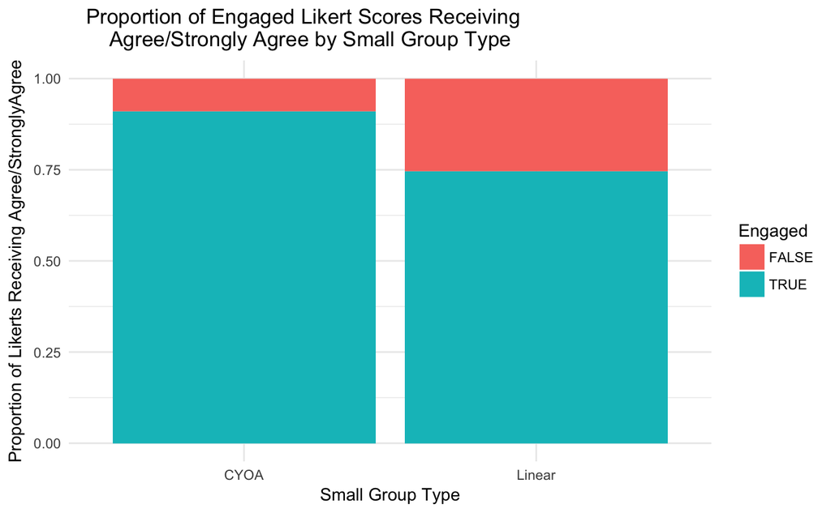

```r
ggplot(data = dichotomized, aes(x = SmallGroupType)) +
  geom_histogram(stat = "count", aes (fill = Engaged), position = "fill") +
  labs(x = "Small Group Type",
       y = "Proportion of Likerts Receiving Agree/StronglyAgree",
       title = "   Proportion of Engaged Likert Scores Receiving
       Agree/Strongly Agree by Small Group Type") +
  theme_minimal()
```

```
Ignoring unknown parameters: binwidth, bins, pad
```

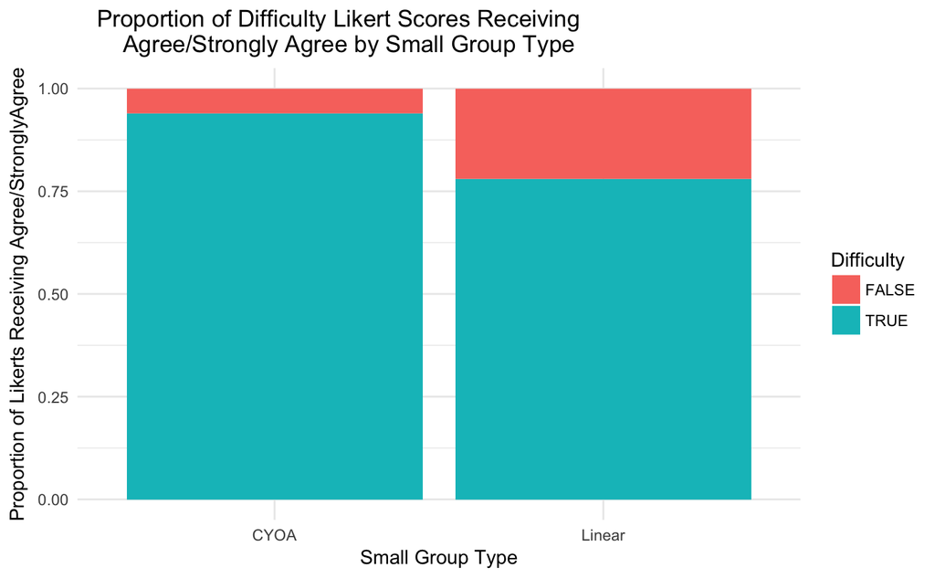

```r
ggplot(data = dichotomized, aes(x = SmallGroupType)) +
  geom_histogram(stat = "count", aes (fill = Difficulty), position = "fill") +
  labs(x = "Small Group Type",
       y = "Proportion of Likerts Receiving Agree/StronglyAgree",
       title = "   Proportion of Difficulty Likert Scores Receiving
       Agree/Strongly Agree by Small Group Type") +
  theme_minimal()
```

```
Ignoring unknown parameters: binwidth, bins, pad
```

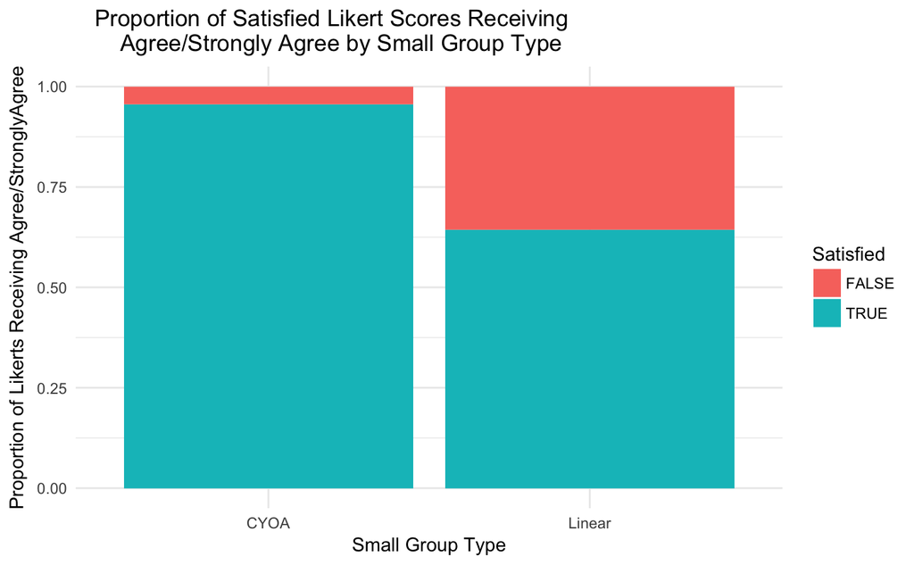

```r
ggplot(data = dichotomized, aes(x = SmallGroupType)) +
  geom_histogram(stat = "count", aes (fill = Satisfied), position = "fill") +
  labs(x = "Small Group Type",
       y = "Proportion of Likerts Receiving Agree/StronglyAgree",
       title = "   Proportion of Satisfied Likert Scores Receiving
       Agree/Strongly Agree by Small Group Type") +
  theme_minimal()
```

```
Ignoring unknown parameters: binwidth, bins, pad
```

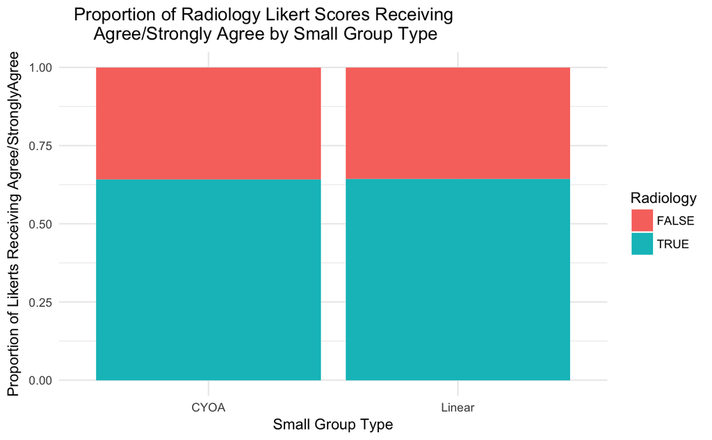

```r
ggplot(data = dichotomized, aes(x = SmallGroupType)) +
  geom_histogram(stat = "count", aes (fill = Radiology), position = "fill")  +
  labs(x = "Small Group Type",
       y = "Proportion of Likerts Receiving Agree/StronglyAgree",
       title = "   Proportion of Radiology Likert Scores Receiving
       Agree/Strongly Agree by Small Group Type") +
  theme_minimal()
```

```
Ignoring unknown parameters: binwidth, bins, pad
```

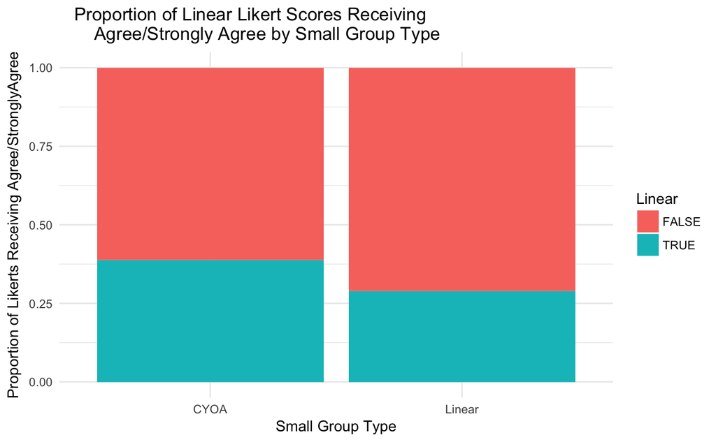

```r
ggplot(data = dichotomized, aes(x = SmallGroupType)) +
  geom_histogram(stat = "count", aes (fill = Linear), position = "fill") +
  labs(x = "Small Group Type",
       y = "Proportion of Likerts Receiving Agree/StronglyAgree",
       title = "   Proportion of Linear Likert Scores Receiving
       Agree/Strongly Agree by Small Group Type") +
  theme_minimal()
```

```
Ignoring unknown parameters: binwidth, bins, pad
```

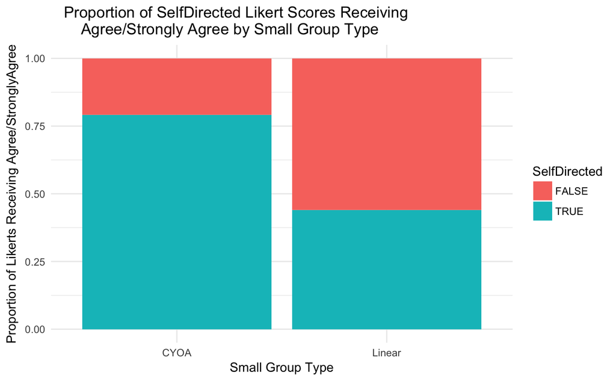

```r
ggplot(data = dichotomized, aes(x = SmallGroupType)) +
  geom_histogram(stat = "count", aes (fill = SelfDirected), position = "fill") +
  labs(x = "Small Group Type",
       y = "Proportion of Likerts Receiving Agree/StronglyAgree",
       title = "   Proportion of SelfDirected Likert Scores Receiving
       Agree/Strongly Agree by Small Group Type") +
  theme_minimal()
```

```
Ignoring unknown parameters: binwidth, bins, pad
```

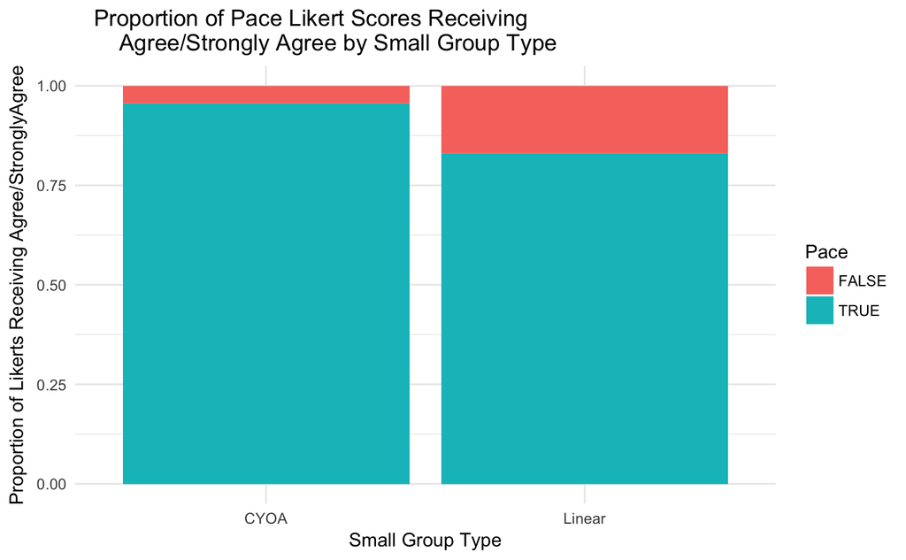

```r
ggplot(data = dichotomized, aes(x = SmallGroupType)) +
  geom_histogram(stat = "count", aes (fill = Pace), position = "fill") +
  labs(x = "Small Group Type",
       y = "Proportion of Likerts Receiving Agree/StronglyAgree",
       title = "   Proportion of Pace Likert Scores Receiving
       Agree/Strongly Agree by Small Group Type") +
  theme_minimal()
```

```
Ignoring unknown parameters: binwidth, bins, pad
```

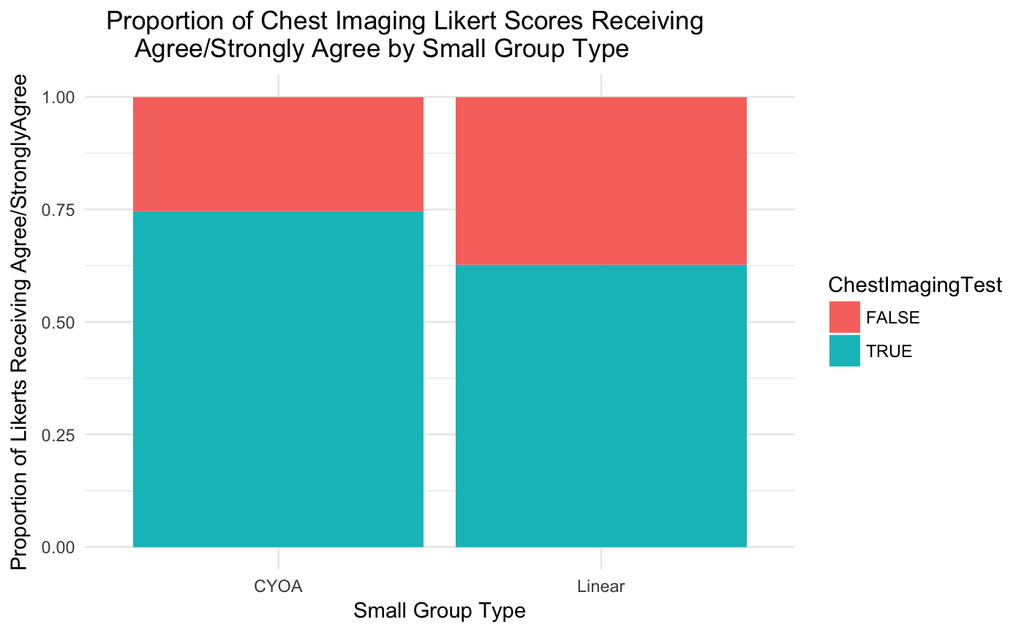

```r
ggplot(data = dichotomized, aes(x = SmallGroupType)) +
  geom_histogram(stat = "count", aes (fill = ChestImagingTest), position = "fill") +
  labs(x = "Small Group Type",
       y = "Proportion of Likerts Receiving Agree/StronglyAgree",
       title = "   Proportion of Chest Imaging Likert Scores Receiving
       Agree/Strongly Agree by Small Group Type") +
  theme_minimal()
```

```
Ignoring unknown parameters: binwidth, bins, pad
```

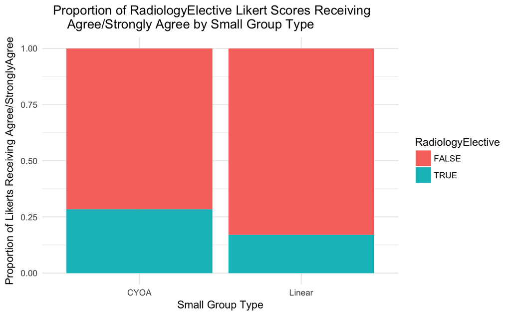

```r
ggplot(data = dichotomized, aes(x = SmallGroupType)) +
  geom_histogram(stat = "count", aes (fill = RadiologyElective), position = "fill")  +
  labs(x = "Small Group Type",
       y = "Proportion of Likerts Receiving Agree/StronglyAgree",
       title = "   Proportion of RadiologyElective Likert Scores Receiving
       Agree/Strongly Agree by Small Group Type") +
  theme_minimal()
```

```
Ignoring unknown parameters: binwidth, bins, pad
```

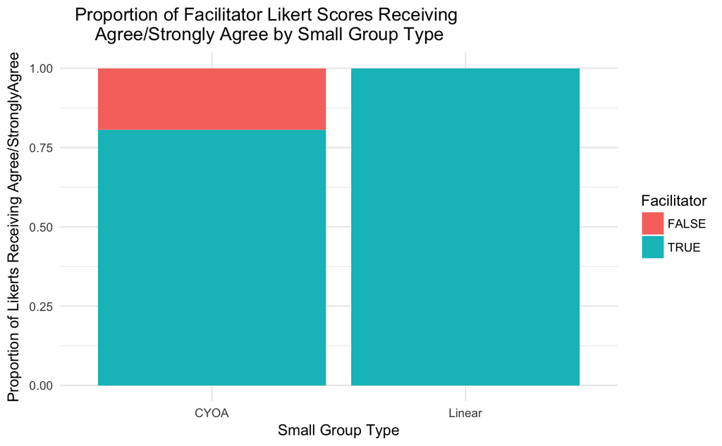

```r
ggplot(data = dichotomized, aes(x = SmallGroupType)) +
  geom_histogram(stat = "count", aes (fill = Facilitator), position = "fill") +
  labs(x = "Small Group Type",
       y = "Proportion of Likerts Receiving Agree/StronglyAgree",
       title = "   Proportion of Facilitator Likert Scores Receiving
       Agree/Strongly Agree by Small Group Type") +
  theme_minimal()
```